# Network Analysis - New Hire Attrition

### The Prompt and Supporting Data

This is an example network analysis looking at a class of new hires in a fake manufacturing company. Our hypothesis is that if they make a friend in their first week, they’re more likely to stay with the company. However, due to data collection limitations, our only way to measure friendship is whether they walk through the turnstiles together before or after their shift.

Packages used in this example.

```r
library(tidyverse);library(readxl);library(igraph);library(ggraph);library(tidygraph)

set.seed(777)
```

Our data is in two parts: the edges and the vertices.Edges being the lines in the network and the vertices being the dots.

```r
raw.edge<-read_excel("New_Emp_Edges.xlsx")

raw.vert<-read_excel("New_Emp_Vertices.xlsx")
```

Our edge data is the turnstile passes and must be heavily transformed before use.

```r
head(raw.edge)
```

```
## # A tibble: 6 × 5
##   Employee Location Direction Date                Time
##      <dbl> <chr>    <chr>     <dttm>              <dttm>
## 1        1 South    IN        2022-01-10 00:00:00 1899-12-31 07:54:47
## 2        1 South    OUT       2022-01-10 00:00:00 1899-12-31 17:20:02
## 3        1 South    IN        2022-01-11 00:00:00 1899-12-31 07:46:09
## 4        1 South    OUT       2022-01-11 00:00:00 1899-12-31 17:18:35
## 5        1 South    IN        2022-01-12 00:00:00 1899-12-31 07:47:46
## 6        1 South    OUT       2022-01-12 00:00:00 1899-12-31 17:15:50
```

Our vertices data is information about each employee and is already in a usable format!

```r
head(raw.vert)
```

```
## # A tibble: 6 × 4
##   Employee Job        Shift Outcome
##      <dbl> <chr>      <chr> <chr>
## 1        1 Logistics  A     Stayed
## 2        2 Production B     Quit
## 3        3 Logistics  A     Stayed
## 4        4 Production A     Stayed
## 5        5 Logistics  A     Stayed
## 6        6 Production A     Stayed
```

### Cleaning the Edge Data

First things first, we need to consolidate our timestamp.

```r
edge.2<-raw.edge %>%
  mutate(Date.Time =
           paste(
             Date,
             str_sub(Time,12,19),
             sep = " ")) %>%
  mutate(Date.Time = as.POSIXct(Date.Time,format="%Y-%m-%d %H:%M:%S"))
```

Now let’s flag when two new employees walked through the turnstiles together (meaning within 3 seconds of each other). We can do this by using a for loop to add and subtract 3 seconds to the timestamp, recombine them, then use pivot_longer to consolidate the stamps into one column.

```r
plusdata<-edge.2
minusdata<-edge.2

for(i in 1:3){
  plus <- plusdata[,ncol(plusdata)]+1                      # Create new column
  plusdata[ , ncol(plusdata) + 1] <- plus                  # Append new column
  colnames(plusdata)[ncol(plusdata)] <- paste0("plus", i)  # Rename column name
}

for(i in 1:3){
  minus <- minusdata[,ncol(minusdata)]-1                      # Create new column
  minusdata[ , ncol(minusdata) + 1] <- minus                  # Append new column
  colnames(minusdata)[ncol(minusdata)] <- paste0("minus", i)  # Rename column name
}

gimmeminus <- minusdata %>% select(starts_with("minus")) #pulls out -3 second times to combine with main data

cleandata <- cbind(plusdata,gimmeminus) #full dataset with times +/- 3

longdata <- pivot_longer(cleandata,
                         cols= starts_with(c("plus","minus")),
                         names_to="stamp") %>% #consolidates all plus or minus columns into one stamp column
                          select(Employee,Location,value)

head(longdata)
```

```
## # A tibble: 6 × 3
##   Employee Location value
##      <dbl> <chr>    <dttm>
## 1        1 South    2022-01-10 07:54:48
## 2        1 South    2022-01-10 07:54:49
## 3        1 South    2022-01-10 07:54:50
## 4        1 South    2022-01-10 07:54:46
## 5        1 South    2022-01-10 07:54:45
## 6        1 South    2022-01-10 07:54:44
```

We can now take this timestamp data and rejoin it with our original data to identify instances where a pair of employees passed through the turnstiles together. Employees may coincidentally walk through together once but twice is more likely to be intentional, so we’ll use it as a cutoff.

```r
coredata<-cleandata %>%
  select(Employee,Location,Date.Time)

combined <- inner_join(coredata,longdata,by=c("Location","Date.Time"="value")) %>%
  select(Employee.x,Employee.y) %>%
  arrange(Employee.x) #Creates a pair of employees if they passed through together then sorts by number

weighted <- combined %>%
  group_by(Employee.x,Employee.y) %>%
  summarize(weight=n()) %>%  #totals the pairs to create a weight
  filter(weight>=2) %>% #implementing our cutoff
  ungroup()

head(weighted)
```

```
## # A tibble: 6 × 3
##   Employee.x Employee.y weight
##        <dbl>      <dbl>  <int>
## 1          5         39      3
## 2          6         15      2
## 3          6         31      2
## 4          6         41      2
## 5         15          6      2
## 6         15         20      2
```

### Visualizing the Network

Now we can use igraph to combine our edges and vertices into a dataset for creating network visuals.

```r
graphdata <- graph_from_data_frame(
  d=weighted,
  vertices=raw.vert,
  directed=F) #Our graph data, not directed because we're looking at pairs

l <- layout_with_fr(graphdata) #Freezes the layout
```

First, our baseline graph.

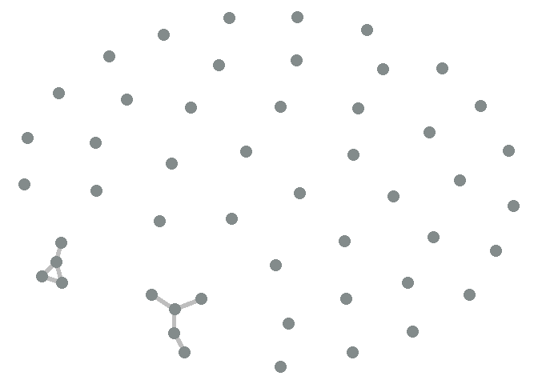

```r
basegraph <- ggraph(graphdata,layout = l)+
  geom_edge_link(color = "grey",width = 2) +
  geom_node_point(color="azure4",size = 5) +
  theme_void()

basegraph
```

Looks like only a few of our new employee class passed through the turnstiles together. Now let’s recolor our edges to learn more about our two “friend groups.”

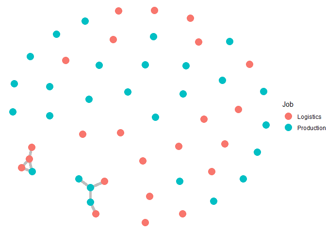

```r
jobgraph <- ggraph(graphdata,layout = l)+
  geom_edge_link(color = "grey",width=2) +
  geom_node_point(size = 5,aes(color=Job)) +
  theme_void()

jobgraph
```

Both are a mix of production and logistics employees.

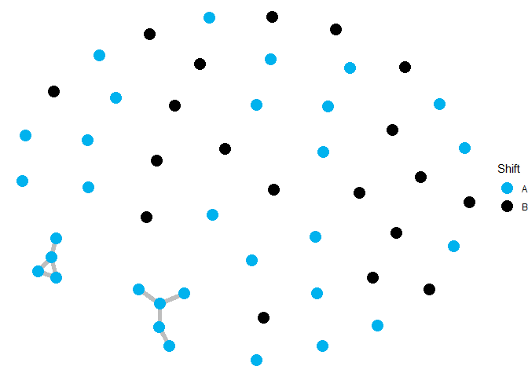

```r
types <- c("A"="deepskyblue2","B"="black") #Changing the colors

shiftgraph <- ggraph(graphdata,layout = l)+
  geom_edge_link(color = "grey",width=2) +
  geom_node_point(size = 5,aes(color=Shift)) +
  scale_color_manual(values=types)+
  theme_void()

shiftgraph
```

Both are only A shift, interestingly.

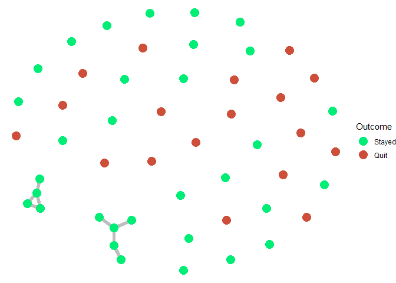

```r
outcomes <- c("Stayed"="springgreen2","Quit"="tomato3") #Changing the colors

stayedgraph <- ggraph(graphdata,layout = l)+
  geom_edge_link(color = "grey",width=2) +
  geom_node_point(size = 5,aes(color=Outcome)) +
  scale_color_manual(values=outcomes)+
  theme_void()

stayedgraph
```

And most importantly, all of the employees in the friend groups stayed with the company! Granted they represent fairly small numbers. Let’s see if the difference is statistically significant using a chi square test.

```r
totals <- weighted %>%
  group_by(Employee.x) %>%
  summarize(connections=sum(weight))

analyzeme <- left_join(raw.vert,totals,by=c("Employee"="Employee.x"))

analyzeme$connections[is.na(analyzeme$connections)] <- 0

analyzeme <- analyzeme %>%
  mutate(connected=ifelse(connections==0,"No","Yes"))

chisq.test(analyzeme$connected,analyzeme$Outcome)
```

```
##
##  Pearson's Chi-squared test with Yates' continuity correction
##
## data:  analyzeme$connected and analyzeme$Outcome
## X-squared = 4.4153, df = 1, p-value = 0.03562
```

We hit the magic p<.05 so of course “connecting” in the first week is truly related to retention, right?

As a next step, we should include more new hire classes to increase our sample size and see if this conclusion changes before taking any action.